# Tugas-Pertemuan-4

Daffa Kyanfaiza G1401231078

2025-09-23

# Soal 1

Melalui program R: • Bangkitkan model MA(2) dengan 𝜃1 = 0.4 dan 𝜃2 = 0.6 sebanyak 300 data (Manual dan dengan arima.sim) • Buat plot time series, plot ACF, plot PACF dan plot EACF. Idenifikasi apakah data tersebut stasioner • Buat scatterplot antara 𝑌𝑡 dengan 𝑌𝑡−1, 𝑌𝑡 dengan 𝑌𝑡−2 serta 𝑌𝑡 dengan 𝑌𝑡−3 • Hitung autokorelasi masing masing baik dari data bangkitan maupun secara teoriti

# Jawab

## White Noise

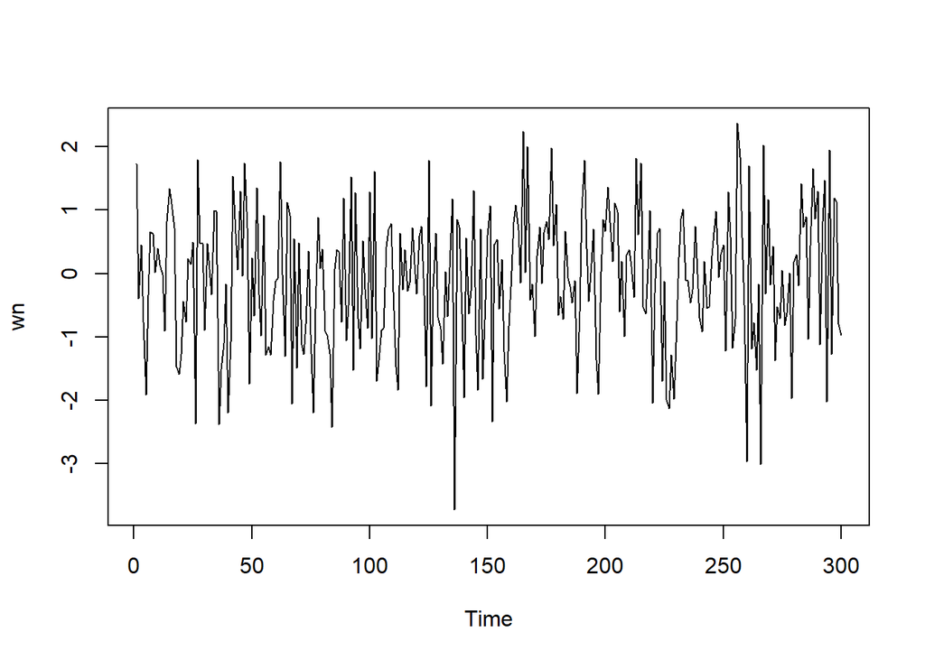

```r
set.seed(1231401078)
wn <- rnorm(300)
ts.plot(wn)
```

## MA(2)

### Manual

```r
set.seed(1231401078)
ma <- c(1:300)
ma[1] <- wn[1]
ma[2] <- ma[2] - 0.4 * ma[1]
```

```r
for(i in 3:300){
   ma[i] <- wn[i] - 0.4 * wn[i - 1] - 0.6 * wn[i - 2]
}
ma
```

```
##   [1]  1.731028257  1.307588697 -0.427657962 -0.709300346 -1.878869275
##   [6]  0.890543128  1.945091383  0.558168849 -0.628560508  0.015190900
##  [11] -0.027337339 -0.306034692 -0.982960442  1.191771659  1.551002929
##  [16]  0.076064952 -0.521466328 -2.419235419 -1.432176479  0.237517974
##  [21]  1.028136843  0.174370687  0.795762694  0.512743512  0.296043372
##  [26] -2.655509833  2.447738295  1.188308813 -0.798027865 -1.366771480
##  [31]  0.545753970  0.420082051 -0.647669885  1.079874182  0.782883131
##  [36] -3.362909177 -1.152877975  0.930504645  1.183772788 -1.464501126
##  [41] -0.102215091  3.286029670  0.670818864 -1.122765035  0.895945327
##  [46] -0.596730623  0.974364875  0.046741523 -3.071184486  0.511188556
##  [51]  0.278920256  1.476390878 -0.475950245 -1.660448644  1.510433058
##  [56] -1.068554743 -1.185694421 -0.056325678  0.779790438  0.818633998
##  [61]  0.227002557  1.874559720 -0.676070598 -2.364721685  1.662441694
##  [66]  1.253374694 -3.094455306  0.817094635 -0.480960136  0.751643869
##  [71] -0.414790717 -1.112379391  0.377513968  1.434153840 -0.623472658
```

[output cut: 45 more lines]

### arima.sim

```r
ma2 <- arima.sim(list(order=c(0,0,2), ma=c(0.4, 0.6)), n=300)
ma2
```

```
## Time Series:
## Start = 1
## End = 300
## Frequency = 1
##   [1]  1.33084332 -0.82612515 -1.95112826 -1.56271118 -0.62177436  0.68419482
##   [7]  0.66237517  0.77413497  0.30868181  0.28009862 -0.82452819  0.45321456
##  [13]  1.12450424  2.13325955  1.96756777 -0.51520014 -1.73828983 -2.79132989
##  [19] -1.89566771 -1.70492881 -0.33697907 -0.22207791  0.68757979 -2.08766121
##  [25]  1.14064377 -0.22224099  1.74142851 -0.40977053  0.40117755 -0.26707054
##  [31] -0.01830637  0.90529058  1.17736329 -1.38771175 -1.87697850 -3.13181050
##  [37] -1.51466344 -2.91764090 -2.05360629 -0.20558410  0.60950426  1.23763156
##  [43]  1.71008581  0.51460175  2.50513201  1.38926295 -0.40908457 -0.01931638
##  [49] -1.61249231  1.23808536 -0.19030298 -0.29826419  0.32719599 -1.50873082
##  [55] -1.11403122 -2.52258727 -1.63161013 -1.06944165 -0.38441232  1.66111123
##  [61]  0.64375193 -0.25624659  0.59466318  0.58363568 -1.00538823  0.27936344
```

[output cut: 39 more lines]

## Plot

### Plot Time Series

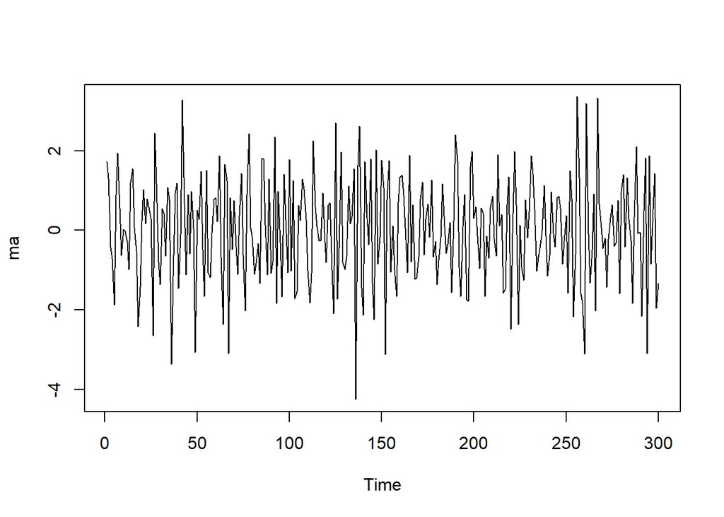

```r
ts.plot(ma)
```

Berdasarkan plot time series, terlihat bahwa data MA(2) yang dibangkitkan stasioner dalam rataan

### Plot ACF

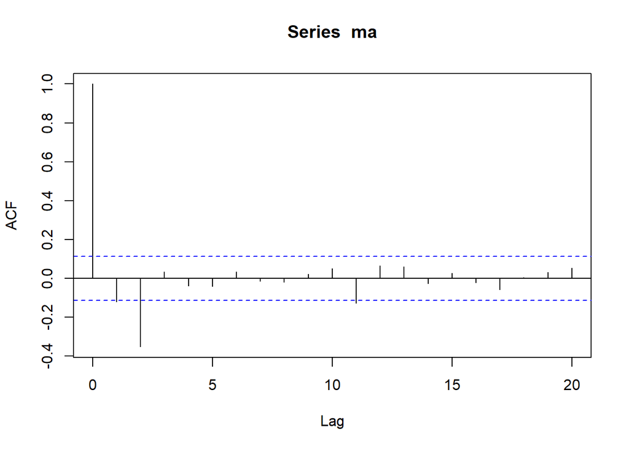

```r
acf(ma,lag.max = 20)
```

Berdasarkan plot AFC tersebut, terlihat bahwa plot ACF cuts off di lag kedua

### Plot PACF

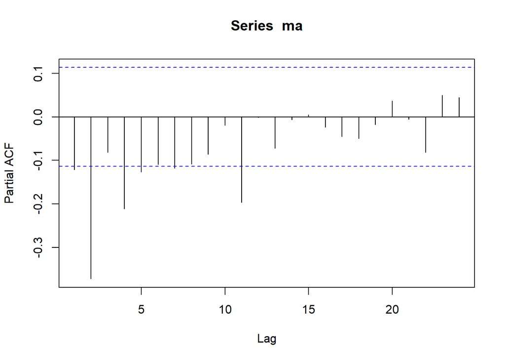

```r
pacf(ma)
```

Berdasarkan plot PACF tersebut, terlihat bahwa plot PACF cenderung tails off dan membentuk gelombang lembah karena nilai teta adalah positif

### Plot EACF

```r
TSA::eacf(ma)
```

```
## AR/MA
##   0 1 2 3 4 5 6 7 8 9 10 11 12 13
## 0 x x o o o o o o o o x  o  o  o
## 1 x x x o o o o o o o o  o  o  o
## 2 x x x x o o o o o o o  o  o  o
## 3 x x x o o o o o o o o  o  o  o
## 4 x o x o o o o o o o o  o  o  o
## 5 x x x x o o o o o o o  o  o  o
## 6 x x x o o o o o o o o  o  o  o
## 7 x o x o o o o o o o o  o  o  o
```

Berdasarkan pola segitiga nol pada plot EACF, terlihat bahwa segitiga nol berada pada ordo AR(0) dan ordo MA(2)

## Scatter Plot Antar Lag

### Korelasi antara Yt dengan Yt−1

```r
yt_ma <- ma[-1]
yt_ma
```

```
##   [1]  1.307588697 -0.427657962 -0.709300346 -1.878869275  0.890543128
##   [6]  1.945091383  0.558168849 -0.628560508  0.015190900 -0.027337339
##  [11] -0.306034692 -0.982960442  1.191771659  1.551002929  0.076064952
##  [16] -0.521466328 -2.419235419 -1.432176479  0.237517974  1.028136843
##  [21]  0.174370687  0.795762694  0.512743512  0.296043372 -2.655509833
##  [26]  2.447738295  1.188308813 -0.798027865 -1.366771480  0.545753970
##  [31]  0.420082051 -0.647669885  1.079874182  0.782883131 -3.362909177
##  [36] -1.152877975  0.930504645  1.183772788 -1.464501126 -0.102215091
##  [41]  3.286029670  0.670818864 -1.122765035  0.895945327 -0.596730623
##  [46]  0.974364875  0.046741523 -3.071184486  0.511188556  0.278920256
##  [51]  1.476390878 -0.475950245 -1.660448644  1.510433058 -1.068554743
##  [56] -1.185694421 -0.056325678  0.779790438  0.818633998  0.227002557
##  [61]  1.874559720 -0.676070598 -2.364721685  1.662441694  1.253374694
##  [66] -3.094455306  0.817094635 -0.480960136  0.751643869 -0.414790717
##  [71] -1.112379391  0.377513968  1.434153840 -0.623472658 -2.026444200
```

[output cut: 45 more lines]

```r
yt_1_ma <- ma[-300]
yt_1_ma
```

```
##   [1]  1.731028257  1.307588697 -0.427657962 -0.709300346 -1.878869275
##   [6]  0.890543128  1.945091383  0.558168849 -0.628560508  0.015190900
##  [11] -0.027337339 -0.306034692 -0.982960442  1.191771659  1.551002929
##  [16]  0.076064952 -0.521466328 -2.419235419 -1.432176479  0.237517974
##  [21]  1.028136843  0.174370687  0.795762694  0.512743512  0.296043372
##  [26] -2.655509833  2.447738295  1.188308813 -0.798027865 -1.366771480
##  [31]  0.545753970  0.420082051 -0.647669885  1.079874182  0.782883131
##  [36] -3.362909177 -1.152877975  0.930504645  1.183772788 -1.464501126
##  [41] -0.102215091  3.286029670  0.670818864 -1.122765035  0.895945327
##  [46] -0.596730623  0.974364875  0.046741523 -3.071184486  0.511188556
##  [51]  0.278920256  1.476390878 -0.475950245 -1.660448644  1.510433058
##  [56] -1.068554743 -1.185694421 -0.056325678  0.779790438  0.818633998
##  [61]  0.227002557  1.874559720 -0.676070598 -2.364721685  1.662441694
##  [66]  1.253374694 -3.094455306  0.817094635 -0.480960136  0.751643869
##  [71] -0.414790717 -1.112379391  0.377513968  1.434153840 -0.623472658
```

[output cut: 45 more lines]

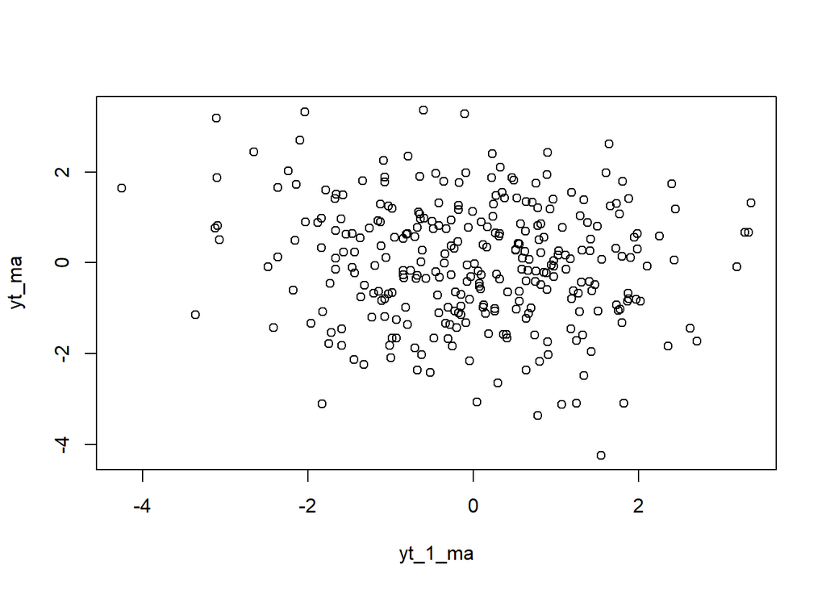

```r
plot(y=yt_ma,x=yt_1_ma)
```

Berdasarkan scatterplot tersebut, terlihat amar samar terdapat hubungan negatif antara Yt dengan Yt−1 .

```r
cor(yt_ma,yt_1_ma)
```

```
## [1] -0.1217628
```

Korelasi antara Yt dengan Yt−1 dari hasil simulasi jika dibulatkan akan mendekati perhitungan teoritis yaitu

### Teoritis

$$\rho_{1} = \frac{-\theta_{1} + \theta_{1}\theta_{2}}{1 + \theta_{1}^{2}
+ \theta_{2}^{2}}
= \frac{-0.4 + 0.4 \times 0.6}{1 + 0.4^{2} + 0.6^{2}}
= -0.105$$

### Korelasi antara Yt dengan Yt−2

```r
yt_ma2 <- ma[-c(1,2)]
yt_ma2
```

```
##   [1] -0.427657962 -0.709300346 -1.878869275  0.890543128  1.945091383
##   [6]  0.558168849 -0.628560508  0.015190900 -0.027337339 -0.306034692
##  [11] -0.982960442  1.191771659  1.551002929  0.076064952 -0.521466328
##  [16] -2.419235419 -1.432176479  0.237517974  1.028136843  0.174370687
##  [21]  0.795762694  0.512743512  0.296043372 -2.655509833  2.447738295
##  [26]  1.188308813 -0.798027865 -1.366771480  0.545753970  0.420082051
##  [31] -0.647669885  1.079874182  0.782883131 -3.362909177 -1.152877975
##  [36]  0.930504645  1.183772788 -1.464501126 -0.102215091  3.286029670
##  [41]  0.670818864 -1.122765035  0.895945327 -0.596730623  0.974364875
##  [46]  0.046741523 -3.071184486  0.511188556  0.278920256  1.476390878
##  [51] -0.475950245 -1.660448644  1.510433058 -1.068554743 -1.185694421
##  [56] -0.056325678  0.779790438  0.818633998  0.227002557  1.874559720
##  [61] -0.676070598 -2.364721685  1.662441694  1.253374694 -3.094455306
##  [66]  0.817094635 -0.480960136  0.751643869 -0.414790717 -1.112379391
##  [71]  0.377513968  1.434153840 -0.623472658 -2.026444200  0.897755135
```

[output cut: 45 more lines]

```r
yt_2_ma <- ma[-c(299,300)]
yt_2_ma
```

```
##   [1]  1.731028257  1.307588697 -0.427657962 -0.709300346 -1.878869275
##   [6]  0.890543128  1.945091383  0.558168849 -0.628560508  0.015190900
##  [11] -0.027337339 -0.306034692 -0.982960442  1.191771659  1.551002929
##  [16]  0.076064952 -0.521466328 -2.419235419 -1.432176479  0.237517974
##  [21]  1.028136843  0.174370687  0.795762694  0.512743512  0.296043372
##  [26] -2.655509833  2.447738295  1.188308813 -0.798027865 -1.366771480
##  [31]  0.545753970  0.420082051 -0.647669885  1.079874182  0.782883131
##  [36] -3.362909177 -1.152877975  0.930504645  1.183772788 -1.464501126
##  [41] -0.102215091  3.286029670  0.670818864 -1.122765035  0.895945327
##  [46] -0.596730623  0.974364875  0.046741523 -3.071184486  0.511188556
##  [51]  0.278920256  1.476390878 -0.475950245 -1.660448644  1.510433058
##  [56] -1.068554743 -1.185694421 -0.056325678  0.779790438  0.818633998
##  [61]  0.227002557  1.874559720 -0.676070598 -2.364721685  1.662441694
##  [66]  1.253374694 -3.094455306  0.817094635 -0.480960136  0.751643869
##  [71] -0.414790717 -1.112379391  0.377513968  1.434153840 -0.623472658
```

[output cut: 45 more lines]

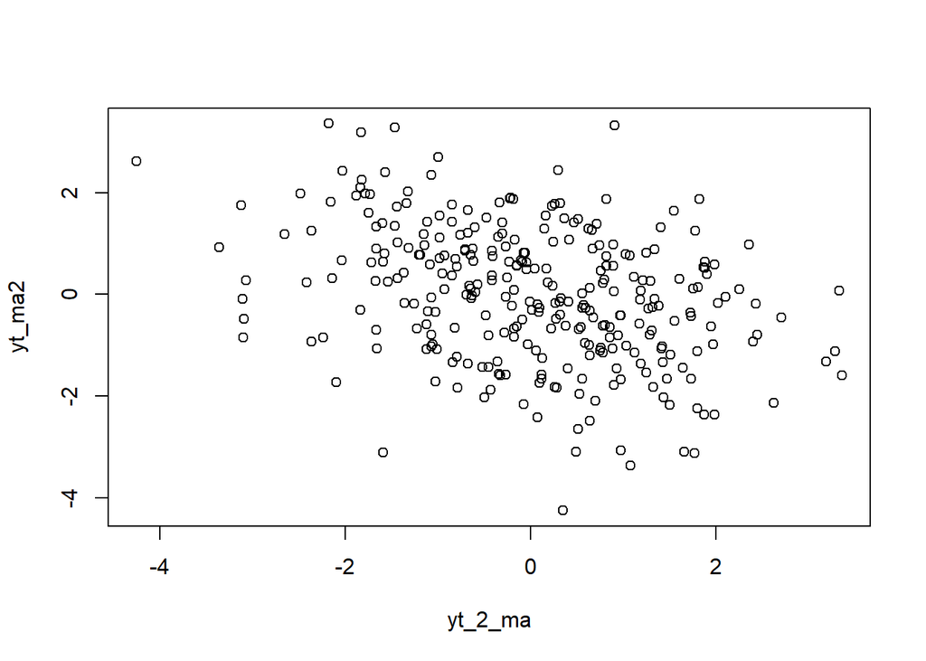

```r
plot(y=yt_ma2,x=yt_2_ma)
```

Berdasarkan scatterplot tersebut, terlihat bahwa terdapat hubungan negatif antara Yt dengan Yt−2.

```r
cor(yt_ma2,yt_2_ma)
```

```
## [1] -0.355053
```

Korelasi antara Yt dengan Yt−2 dari hasil simulasi tergolong mendekati perhitungan teoritis yaitu

### Teoritis

$$\rho_{2} = \frac{-\theta_{2}}{1 + \theta_{1}^{2} + \theta_{2}^{2}}
= \frac{-0.6}{1 + 0.4^{2} + 0.6^{2}}
= -0.394$$

### Korelasi antara Yt dengan Yt−3

```r
yt_ma3 <- ma[-c(1,2,3)]
yt_ma3
```

```
##   [1] -0.709300346 -1.878869275  0.890543128  1.945091383  0.558168849
##   [6] -0.628560508  0.015190900 -0.027337339 -0.306034692 -0.982960442
##  [11]  1.191771659  1.551002929  0.076064952 -0.521466328 -2.419235419
##  [16] -1.432176479  0.237517974  1.028136843  0.174370687  0.795762694
##  [21]  0.512743512  0.296043372 -2.655509833  2.447738295  1.188308813
##  [26] -0.798027865 -1.366771480  0.545753970  0.420082051 -0.647669885
##  [31]  1.079874182  0.782883131 -3.362909177 -1.152877975  0.930504645
##  [36]  1.183772788 -1.464501126 -0.102215091  3.286029670  0.670818864
##  [41] -1.122765035  0.895945327 -0.596730623  0.974364875  0.046741523
##  [46] -3.071184486  0.511188556  0.278920256  1.476390878 -0.475950245
##  [51] -1.660448644  1.510433058 -1.068554743 -1.185694421 -0.056325678
##  [56]  0.779790438  0.818633998  0.227002557  1.874559720 -0.676070598
##  [61] -2.364721685  1.662441694  1.253374694 -3.094455306  0.817094635
##  [66] -0.480960136  0.751643869 -0.414790717 -1.112379391  0.377513968
##  [71]  1.434153840 -0.623472658 -2.026444200  0.897755135  2.431880299
```

[output cut: 45 more lines]

```r
yt_3_ma <- ma[-c(288, 299,300)]
yt_3_ma
```

```
##   [1]  1.731028257  1.307588697 -0.427657962 -0.709300346 -1.878869275
##   [6]  0.890543128  1.945091383  0.558168849 -0.628560508  0.015190900
##  [11] -0.027337339 -0.306034692 -0.982960442  1.191771659  1.551002929
##  [16]  0.076064952 -0.521466328 -2.419235419 -1.432176479  0.237517974
##  [21]  1.028136843  0.174370687  0.795762694  0.512743512  0.296043372
##  [26] -2.655509833  2.447738295  1.188308813 -0.798027865 -1.366771480
##  [31]  0.545753970  0.420082051 -0.647669885  1.079874182  0.782883131
##  [36] -3.362909177 -1.152877975  0.930504645  1.183772788 -1.464501126
##  [41] -0.102215091  3.286029670  0.670818864 -1.122765035  0.895945327
##  [46] -0.596730623  0.974364875  0.046741523 -3.071184486  0.511188556
##  [51]  0.278920256  1.476390878 -0.475950245 -1.660448644  1.510433058
##  [56] -1.068554743 -1.185694421 -0.056325678  0.779790438  0.818633998
##  [61]  0.227002557  1.874559720 -0.676070598 -2.364721685  1.662441694
##  [66]  1.253374694 -3.094455306  0.817094635 -0.480960136  0.751643869
##  [71] -0.414790717 -1.112379391  0.377513968  1.434153840 -0.623472658
```

[output cut: 45 more lines]

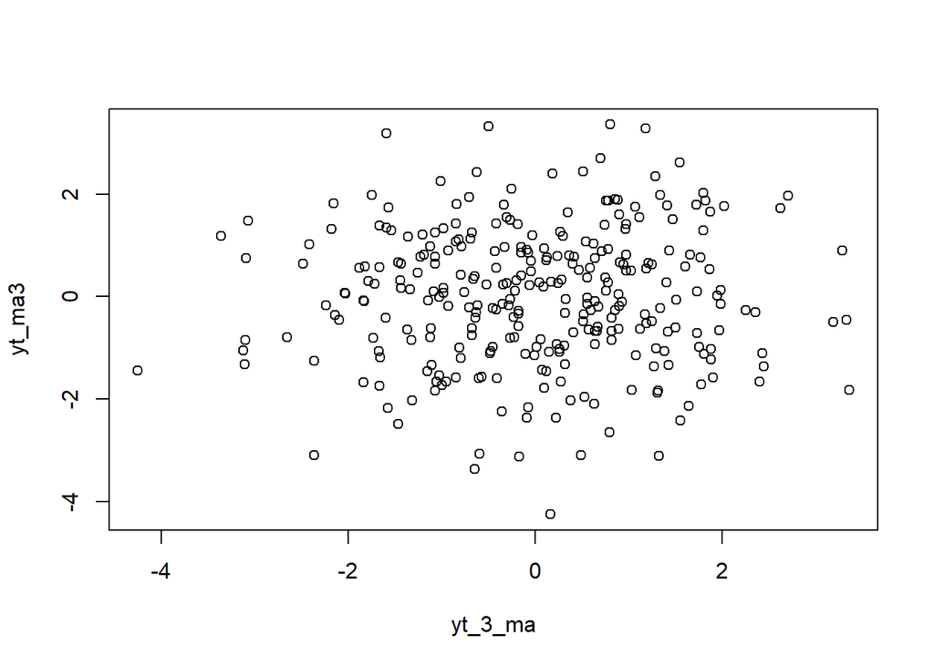

```r
plot(y=yt_ma3,x=yt_3_ma)
```

Berdasarkan scatterplot tersebut, terlihat bahwa Yt dan Yt−3 sudah menunjukkan pola yang tidak beraturan atau bisa disebut tidak berpola.

```r
cor(yt_ma3,yt_3_ma)
```

```
## [1] 0.02336161
```

Korelasi antara Yt dengan Yt−3 dari hasil simulasi mendekati nilai teoritis yang menyatakan bahwa ρk=0 untuk k>q

### Teoritis

$$\rho_{3} = 0$$